# Stock Multiple Linear Regression Analysis: QQQ

By Thomas Wang (University of California, Davis)

**Contact:** Twan92537@gmail.com

## Introduction

As someone who is invested in data analysis and stock trading, I wanted to apply the statistical methods that I learned to real-world financial data. I chose to analyze QQQ (Invesco Nasdaq-100 ETF), which tracks the 100 largest non-financial companies on the Nasdaq — including major tech names like Apple, Microsoft, and NVIDIA.

### Research Question

**Can technical indicators from historical price and volume data predict next-day returns for QQQ?**

Specifically, I investigate whether technical indicators derived from price and volume data — such as daily returns, short-term momentum, volatility, and volume changes — have statistically significant predictive power for next-day returns.

### Approach

This project follows a complete regression analysis workflow:

1. **Data Collection & Feature Engineering**: Download 5 years of QQQ daily data (2020–2025) and construct four predictor variables.
2. **Model Fitting**: Fit a multiple linear regression model using OLS and interpret the coefficients, hypothesis tests, and R².
3. **Model Comparison**: Use the Partial F-test to compare a full model (4 predictors) against a reduced model (1 predictor) and determine which is preferred.
4. **Diagnostics**: Verify OLS assumptions through VIF, Q-Q plots, residual analysis, leverage, and Cook's Distance.

This project demonstrates how statistical theory connects to practical financial analysis, applying concepts such as the F-test, t-test, ANOVA decomposition, VIF, and residual diagnostics to real market data.

## Part 1: Data Collection & Feature Engineering

We download QQQ daily data from 2020-2025 and construct four features to predict next-day returns.

### Feature Definitions

- **1d_return** (predictor): Daily return, calculated as percentage change in closing price
- **5d_return** (predictor): 5-day cumulative return (momentum)
- **10d_volatility** (predictor): Standard deviation of daily returns over a 10-day rolling window
- **vol_change** (predictor): Daily percentage change in trading volume
- **nextday_return** (response): Next-day return

```python
import yfinance as yf
import pandas as pd
import numpy as np
import matplotlib.pyplot as plt
import statsmodels.api as sm
from statsmodels.stats.outliers_influence import variance_inflation_factor

df = yf.download("QQQ", start="2020-01-01", end="2025-12-31",progress=False)
df.columns = df.columns.get_level_values(0)

df['1d_return'] = df['Close'].pct_change() #predictor variable
df['5d_return'] = df['Close'].pct_change(5) #predictor variable
df['10d_volatility'] = df['1d_return'].rolling(window=10).std() #predictor variable
df['vol_change'] = df['Volume'].pct_change() #predictor variable
df['nextday_return'] = df['1d_return'].shift(-1) #response variable
df.dropna(inplace=True)

features = ['1d_return', '5d_return', '10d_volatility', 'vol_change']
X = sm.add_constant(df[features])
y = df['nextday_return']
```

## Part 2: Model Fitting

We use Ordinary Least Squares (OLS) to estimate the linear relationship between our four predictor variables and next-day returns for QQQ.

### Model Specification

$$Y_i = \beta_0 + \beta_1(1d\_return) + \beta_2(5d\_return) + \beta_3(10d\_volatility) + \beta_4(vol\_change) + \varepsilon_i$$

where $\varepsilon_i \sim N(0, \sigma^2)$ independently.

### Estimation Method

The OLS estimator minimizes the sum of squared residuals:

$$\hat{\beta} = (X^TX)^{-1}X^TY$$

This produces the Best Linear Unbiased Estimator under the Gauss-Markov assumptions:

1. **Linearity**: The relationship between predictors and response is linear
2. **Independence**: Observations are independent of each other
3. **Homoscedasticity**: Constant variance of errors ($Var(\varepsilon_i) = \sigma^2$)
4. **Normality**: Errors are normally distributed

We will verify these assumptions in Part 4 (Diagnostics).

```python
model = sm.OLS(y, X).fit()
print(model.summary())
```

```
                            OLS Regression Results
==============================================================================
Dep. Variable:         nextday_return   R-squared:                       0.021
Model:                            OLS   Adj. R-squared:                  0.018
Method:                 Least Squares   F-statistic:                     7.987
Date:                Thu, 02 Apr 2026   Prob (F-statistic):           2.27e-06
Time:                        23:18:37   Log-Likelihood:                 4080.6
No. Observations:                1496   AIC:                            -8151.
Df Residuals:                    1491   BIC:                            -8125.
Df Model:                           4
Covariance Type:            nonrobust
==================================================================================
                     coef    std err          t      P>|t|      [0.025      0.975]
----------------------------------------------------------------------------------
const              0.0008      0.001      1.038      0.300      -0.001       0.002
1d_return         -0.1490      0.029     -5.150      0.000      -0.206      -0.092
5d_return         -0.0003      0.014     -0.018      0.985      -0.028       0.027
10d_volatility     0.0144      0.050      0.289      0.773      -0.083       0.112
vol_change        -0.0018      0.001     -1.359      0.174      -0.004       0.001
==============================================================================
Omnibus:                      212.276   Durbin-Watson:                   1.987
Prob(Omnibus):                  0.000   Jarque-Bera (JB):             2253.791
Skew:                          -0.255   Prob(JB):                         0.00
Kurtosis:                       8.991   Cond. No.                         121.
==============================================================================

Notes:
[1] Standard Errors assume that the covariance matrix of the errors is correctly specified.
```

### Model Summary Interpretation

**Hypothesis Test (Overall F-test)**:

- $H_0: \beta_1 = \beta_2 = \beta_3 = \beta_4 = 0$ (no predictor has a linear relationship with next-day returns)
- $H_1:$ At least one $\beta_j \neq 0$ (at least one predictor is related to nextday_return)
- F = 7.988, p-value = 2.27e-06 < 0.05
- **Conclusion**: At the $\alpha = 0.05$ significance level, we reject $H_0$. There is strong evidence that at least one predictor has a statistically significant relationship with next-day returns.

**R-squared**: R² = 0.021, meaning the model explains only 2.1% of the variance in next-day returns. However, this is **considered** normal in the financial world considering all other noise (news, earnings, political changes, regulation changes...)

**Individual Coefficient t-tests**:

For each predictor, we test:

- $H_0: \beta_j = 0$ (predictor $j$ has no effect on nextday_return)
- $H_1: \beta_j \neq 0$ (predictor $j$ has an effect on nextday_return)

**Coefficient Interpretation**

- Each $\hat{\beta}_j$ represents the expected change in next-day return for a one-unit increase in that predictor, **holding all other predictors constant**.
- We use a significance level of $\alpha = 0.05$ throughout this analysis. If the p-value of a test is less than 0.05, we reject $H_0$ and conclude the result is significant.
- **1d_return** ($\hat{\beta}_1$ = -0.1490): Significant. For every 1% increase in today's return, next-day return is expected to decrease by 0.149%, holding all other predictors constant, which suggests a mean-reversion effect.
- **5d_return** ($\hat{\beta}_2$ = -0.0003): Not significant (p = 0.985). Past-week momentum does not predict next-day returns.
- **10d_volatility** ($\hat{\beta}_3$ = 0.0144): Not significant (p = 0.772). We cannot conclude that recent volatility predicts next-day returns.
- **vol_change** ($\hat{\beta}_4$ = -0.0018): Not significant (p = 0.174), but shows weak evidence that volume spikes may slightly predict negative next-day returns.

### ANOVA Decomposition

We decompose the total variability (SST) into explained variability (SSR) and unexplained variability (SSE):

$$SST = SSR + SSE$$

where:

- $SST = \sum(Y_i - \bar{Y})^2$ — Total Sum of Squares (total variability in next-day returns)
- $SSR = \sum(\hat{Y}_i - \bar{Y})^2$ — Regression Sum of Squares (variability explained by the model)
- $SSE = \sum(Y_i - \hat{Y}_i)^2$ — Error Sum of Squares (variability the model cannot explain)

The F-statistic tests whether SSR is large enough relative to SSE:

$$F = \frac{MSR}{MSE} = \frac{SSR/(p-1)}{SSE/(n-p)}$$

```python
y_hat = model.fittedvalues
y_bar = y.mean()
n, p = X.shape

SST = np.sum((y - y_bar)**2)
SSR = np.sum((y_hat - y_bar)**2)
SSE = np.sum((y - y_hat)**2)
MSR = SSR / (p - 1)
MSE = SSE / (n - p)
F_stat = MSR / MSE

anova_table = pd.DataFrame({
    'Source': ['Regression', 'Error', 'Total'],
    'SS': [SSR, SSE, SST],
    'df': [p - 1, n - p, n - 1],
    'MS': [MSR, MSE, None],
    'F': [F_stat, None, None]
})
print(anova_table.to_string(index=False))
```

```
    Source       SS   df       MS        F
Regression 0.008021    4 0.002005 7.987478
     Error 0.374319 1491 0.000251      NaN
     Total 0.382340 1495      NaN      NaN
```

### ANOVA Explanation

- **SST (Total)** = 0.382: The total error when predicting with just the mean $\bar{Y}$
- **SSR (Regression)** = 0.008: The error reduced by using our model instead of the mean
- **SSE (Error)** = 0.374: The error still remaining after using our model

$$SST = SSR + SSE$$ $$0.382 = 0.008 + 0.374$$

The model reduces only 2.1% of the total error (R² = SSR/SST = 0.021). However, the F-test (F = 7.988, p = 2.27e-06) confirms this reduction is statistically significant and not due to random chance.

## Part 3: Partial F-test (Model Comparison)

Since only 1d_return is statistically significant in the full model, we compare it against a reduced model to test whether the other three predictors are necessary.

**Full Model**: $Y_i = \beta_0 + \beta_1(1d\_return) + \beta_2(5d\_return) + \beta_3(10d\_volatility) + \beta_4(vol\_change) + \varepsilon_i$

**Reduced Model**: $Y_i = \beta_0 + \beta_1(1d\_return) + \varepsilon_i$

- $H_0: \beta_2 = \beta_3 = \beta_4 = 0$ (the three additional predictors are not needed)
- $H_1:$ At least one of $\beta_2, \beta_3, \beta_4 \neq 0$

$$F = \frac{(SSE_R - SSE_F) / q}{SSE_F / (n - p_F)}$$

where $q = 3$ (predictors removed) and $p_F = 5$ (parameters in the full model).

```python
# Reduced model
X_reduced = X[['const', '1d_return']]
model_reduced = sm.OLS(y, X_reduced).fit()
print(model_reduced.summary())

# Partial F-test
SSE_R = np.sum(model_reduced.resid**2)
SSE_F = np.sum(model.resid**2)
q = 3

from scipy import stats
F_partial = ((SSE_R - SSE_F) / q) / (SSE_F / (n - p))
p_value = 1 - stats.f.cdf(F_partial, q, n - p)

print(f"\nPartial F-test")
print(f"SSE_Reduced = {SSE_R:.6f}")
print(f"SSE_Full    = {SSE_F:.6f}")
print(f"Partial F   = {F_partial:.4f}")
print(f"p-value     = {p_value:.6f}")
```

```
                            OLS Regression Results
==============================================================================
Dep. Variable:         nextday_return   R-squared:                       0.020
Model:                            OLS   Adj. R-squared:                  0.019
Method:                 Least Squares   F-statistic:                     30.01
Date:                Thu, 02 Apr 2026   Prob (F-statistic):           5.04e-08
Time:                        23:18:37   Log-Likelihood:                 4079.6
No. Observations:                1496   AIC:                            -8155.
Df Residuals:                    1494   BIC:                            -8145.
Df Model:                           1
Covariance Type:            nonrobust
==============================================================================
                 coef    std err          t      P>|t|      [0.025      0.975]
------------------------------------------------------------------------------
const          0.0010      0.000      2.331      0.020       0.000       0.002
1d_return     -0.1403      0.026     -5.478      0.000      -0.191      -0.090
==============================================================================
Omnibus:                      210.441   Durbin-Watson:                   1.985
Prob(Omnibus):                  0.000   Jarque-Bera (JB):             2304.159
Skew:                          -0.224   Prob(JB):                         0.00
Kurtosis:                       9.063   Cond. No.                         62.5
==============================================================================

Notes:
[1] Standard Errors assume that the covariance matrix of the errors is correctly specified.

Partial F-test
SSE_Reduced = 0.374811
SSE_Full    = 0.374319
Partial F   = 0.6543
p-value     = 0.580256
```

**Coefficient Stability**: The coefficient for 1d_return remains stable between the full model ($\hat{\beta}_1$ = -0.1490) and the reduced model ($\hat{\beta}_1$ = -0.1403), confirming that multicollinearity from the removed predictors had minimal impact on this estimate.

### Model Comparison

- **Adj. R²** improves from 0.018 (full) to 0.019 (reduced), meaning the extra predictors were actually hurting the model performance.
- **AIC** decreases from -8151 to -8155, favoring reduced model.
- **BIC** decreases from -8125 to -8145, showing an especially strong preference for the reduced model since BIC penalizes additional parameters more heavily.
- **Conclusion**: The single-predictor model with only 1d_return is preferred.

## Part 4: VIF & Residual Diagnostics

### Multicollinearity Check (VIF)

We check for multicollinearity among the predictors in our full model using the Variance Inflation Factor:

$$VIF_j = \frac{1}{1 - R^2_j}$$

where $R^2_j$ is the R² from regressing predictor $X_j$ on all other predictors. A VIF > 10 indicates severe multicollinearity.

### Residual Diagnostics

We verify the OLS assumptions by examining the residuals of our reduced model:

```
          Feature       VIF
0       1d_return  1.275215
1       5d_return  1.224845
2  10d_volatility  1.018446
3      vol_change  1.066839
```

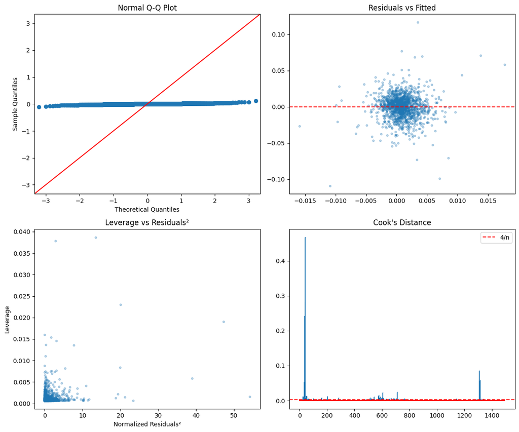

```python
vif_df = pd.DataFrame({
    'Feature': features,
    'VIF': [variance_inflation_factor(X.values, i + 1) for i in range(len(features))]
})
print(vif_df)


fig, axes = plt.subplots(2, 2, figsize=(12, 10))

influence = model_reduced.get_influence()
cooks_d = influence.cooks_distance[0]
hat_values = influence.hat_matrix_diag
resid_norm = (model_reduced.resid / model_reduced.resid.std())**2

# 1. Q-Q
sm.qqplot(model_reduced.resid, line='45', ax=axes[0, 0])
axes[0, 0].set_title('Normal Q-Q Plot')

# 2. Residuals vs Fitted
axes[0, 1].scatter(model_reduced.fittedvalues, model_reduced.resid, alpha=0.3, s=10)
axes[0, 1].axhline(0, color='red', linestyle='--')
axes[0, 1].set_title('Residuals vs Fitted')

# 3. Leverage vs Residuals²
axes[1, 0].scatter(resid_norm, hat_values, alpha=0.3, s=10)
axes[1, 0].set_xlabel('Normalized Residuals²')
axes[1, 0].set_ylabel('Leverage')
axes[1, 0].set_title('Leverage vs Residuals²')

# 4. Cook's Distance
axes[1, 1].stem(cooks_d, markerfmt=',', linefmt='C0-', basefmt='r-')
axes[1, 1].axhline(4 / len(cooks_d), color='red', linestyle='--', label='4/n')
axes[1, 1].set_title("Cook's Distance")
axes[1, 1].legend()

plt.tight_layout()
plt.show()
```

### VIF Results

All VIF values are close to 1 (well below the threshold of 10), indicating **no multicollinearity** among the predictors. Each predictor provides independent information, and the coefficient estimates are not inflated by correlated features.

### Diagnostic Interpretation

- **Q-Q Plot**: The residuals deviate from the 45° line, meaning the normality assumption is not fully met. The model summary confirms this with a Kurtosis of 9.063 (normal = 3), indicating that extreme daily returns (large gains or losses) occur more frequently than a normal distribution would predict. This is a common characteristic of the stock market due to possible Black Swan events such as Covid-19 crash or 2025 tariffs selloff.
- **Residuals vs Fitted**: No obvious pattern, supporting linearity assumption.
- **Leverage vs Residuals²**: Most points cluster near the origin. A few extreme points (likely due to extreme market events such as the 2020 COVID crash or 2025 tariff-driven selloff) have high leverage and large residuals.
- **Cook's Distance**: One observation has a Cook's Distance of approximately 0.5, far exceeding the 4/n = 0.0027 threshold. This means if we removed this single data point, our regression coefficients would change significantly. This influential point is likely an extreme market day with an unusually large price swing, most likely due to Black Swan events.

## Conclusion

**Key Findings**:

- The overall F-test (F = 7.988, p = 2.27e-06) confirmed that the full model is statistically significant, meaning at least one predictor has real predictive power.
- Among the four predictors, only **1d_return** was statistically significant ($\hat{\beta}_1$ = -0.149, p < 0.001), suggesting a **mean-reversion effect** — For every 1% increase in today's return, next-day return is expected to **decrease** by 0.149%, holding all other predictors constant.
- The Partial F-test (F = 0.654, p = 0.580) confirmed that the other three predictors (5d_return, 10d_volatility, vol_change) do not significantly improve the model.
- The **reduced model** with only 1d_return outperformed the full model across every metric: higher Adj. R² (0.019 vs 0.018), lower AIC (-8155 vs -8151), and lower BIC (-8145 vs -8125). The coefficient for 1d_return remained stable between the full model ($\hat{\beta}_1$ = -0.149) and the reduced model ($\hat{\beta}_1$ = -0.140), confirming the robustness of this estimate.
- R² = 0.020 for the reduced model, meaning it explains 2.0% of the variance in next-day returns — nearly identical to the full model's 2.1%. This is expected in financial markets where daily returns are dominated by unpredictable noise such as news, earnings, and political events.
- VIF values were all close to 1, confirming no multicollinearity issues in the full model.
- Residual diagnostics revealed heavy tails (Kurtosis = 9.063), which is typical for financial data due to extreme market events such as the 2020 COVID crash and 2025 tariffs selloff. The linearity and constant variance assumptions appear reasonable.

**Limitations**:

- The model uses only price and volume-based features. Incorporating fundamental data (earnings, economic indicators) or sentiment data (news, social media) could improve predictive power.
- The normality assumption is violated due to heavy tails, which may affect the reliability of confidence intervals and p-values.
- Past patterns do not guarantee future performance — the mean-reversion effect observed here may weaken or disappear over time.

### Answer to Research Question

The data provides evidence **against** the strong form of the Efficient Market Hypothesis and **in favor of** a weak mean-reversion effect in QQQ's daily returns.

My analysis found that today's daily return (1d_return) is a statistically significant predictor of next-day returns ($\hat{\beta}_1$ = -0.140, p < 0.001). The negative coefficient indicates that when QQQ rises today, it tends to fall slightly the next day, and vice versa. This is consistent with the mean-reversion theory.

However, the predictive power is very limited (R² = 0.020), meaning the model only explains 2% of the QQQ behavior. The other three predictors — 5-day momentum, 10-day volatility, and volume change — showed no significant predictive power, and the Partial F-test confirmed they are unnecessary.

In summary: **yes, there is a statistically significant pattern, but it is far too weak to serve as a standalone trading strategy.** The stock market is determined not only by the candlestick chart, but also by real-world news, political events, earnings reports, and many other factors, which is extremely difficult to predict.